# R for Journalists

## Introduction to R for Journalists: How to Find Great Stories in Data

### Here are my course notes for Andrew Tran’s five week course on R for journalists. The course started on July 23, 2018 and will end on August 26, 2018. [Course link](https://journalismcourses.org/course/view.php?id=9)

# Week 1

During the first week we covered the basics of the R language. I know most of these commands which I documented in my other R github repo here: [RstatsInTheBatcave](https://github.com/megomars/RStatisticsInTheBatcave) and here: TidyverseInTheBatcave.

This is what we did in week 1: - A tour of the RStudio IDE - *complete* - Syntax for coding in R - *complete* - Vectors - Matrices - Data frames - Lists - Functions - Creating R scripts - *complete* - Importing packages - *complete* - Good habits for workflow and documentation habits *complete* - How to import data like CSVs, Excel spreadsheets, XML *complete* - csv - here we can either use the Readr package or Base R. - excel - here we used the read_excel package. - delimited data - here we use base R and read.table or read_delim - JSON data - here we used the jsonlite package - SPSS data - here we used base R’s read.spss() - Copying and pasting data

Quick recap of the main commands:

```r
#set working directory
setwd("~/projects/learn-r-journalism")
```

[output not shown]

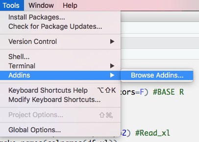

Enabling

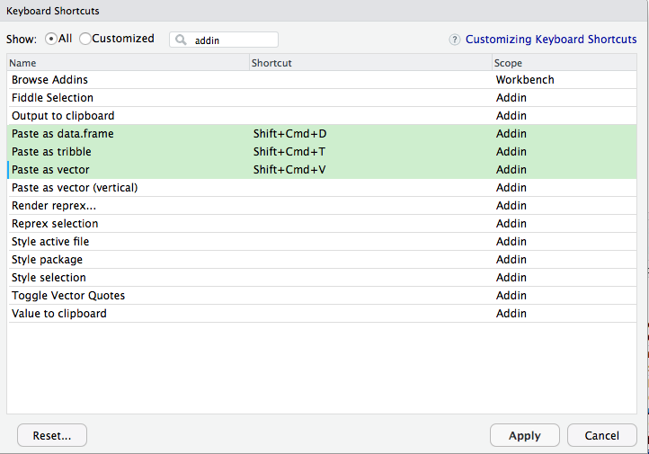

Setting shortcuts

# Week 2

- Wrangling data with the dplyr and tidyr packages. Dplyr is used to explore and transform data-frames.

The basic verbs are:

```r
#filter()
#select()
#arrange()
#mutate()
#summarize()
#group_by()
```

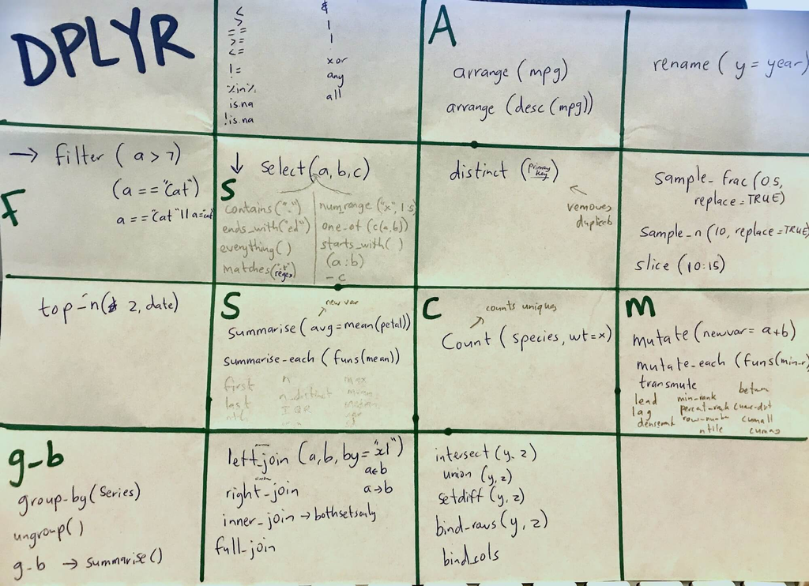

Dplyr cheatsheet

# Week 3

- Visualising data with ggplot2.